# DATA SCIENCE LATAM

### Medias móviles de medias móviles

Es posible aplicar un promedio móvil a un promedio móvil. Una razón para hacerlo es hacer una media móvil de orden par simétrica.

Por ejemplo, podríamos tomar un promedio móvil de orden 4 y luego aplicar otro promedio móvil de orden 2 a los resultados. En la siguiente tabla, esto se ha hecho durante los primeros años de los datos trimestrales de producción de cerveza de Australia.

```r
beer2 <- window(ausbeer,start=1992)

#     Qtr1 Qtr2 Qtr3 Qtr4
#1992  443  410  420  532
#1993  433  421  410  512
#1994  449  381  423  531
#1995  426  408  416  520
#1996  409  398  398  507
#1997  432  398  406  526
#1998  428  397  403  517
#1999  435  383  424  521
#2000  421  402  414  500
#2001  451  380  416  492
#2002  428  408  406  506
#2003  435  380  421  490
#2004  435  390  412  454
#2005  416  403  408  482
#2006  438  386  405  491
#2007  427  383  394  473
#2008  420  390  410  488
#2009  415  398  419  488
#2010  414  374
```

```r
ma4 <- ma(beer2, order=4, centre=FALSE)

#       Qtr1   Qtr2   Qtr3   Qtr4
#1992     NA 451.25 448.75 451.50
#1993 449.00 444.00 448.00 438.00
#1994 441.25 446.00 440.25 447.00
#1995 445.25 442.50 438.25 435.75
#1996 431.25 428.00 433.75 433.75
#1997 435.75 440.50 439.50 439.25
#1998 438.50 436.25 438.00 434.50
#1999 439.75 440.75 437.25 442.00
#2000 439.50 434.25 441.75 436.25
#2001 436.75 434.75 429.00 436.00
#2002 433.50 437.00 438.75 431.75
#2003 435.50 431.50 431.50 434.00
#2004 431.75 422.75 418.00 421.25
#2005 420.25 427.25 432.75 428.50
#2006 427.75 430.00 427.25 426.50
#2007 423.75 419.25 417.50 419.25
#2008 423.25 427.00 425.75 427.75
#2009 430.00 430.00 429.75 423.75
#2010     NA     NA
```

```r
ma2x4 <- ma(beer2, order=4, centre=TRUE)

#         Qtr1    Qtr2    Qtr3    Qtr4
#1992      NA      NA 450.000 450.125
#1993 450.250 446.500 446.000 443.000
#1994 439.625 443.625 443.125 443.625
#1995 446.125 443.875 440.375 437.000
#1996 433.500 429.625 430.875 433.750
#1997 434.750 438.125 440.000 439.375
#1998 438.875 437.375 437.125 436.250
#1999 437.125 440.250 439.000 439.625
#2000 440.750 436.875 438.000 439.000
#2001 436.500 435.750 431.875 432.500
#2002 434.750 435.250 437.875 435.250
#2003 433.625 433.500 431.500 432.750
#2004 432.875 427.250 420.375 419.625
#2005 420.750 423.750 430.000 430.625
#2006 428.125 428.875 428.625 426.875
#2007 425.125 421.500 418.375 418.375
#2008 421.250 425.125 426.375 426.750
#2009 428.875 430.000 429.875 426.750
#2010      NA      NA
#
```

La notación "2×4-MA” en la última columna significa un 4-MA seguido de un 2-MA. Los valores en la última columna se obtienen tomando un promedio móvil de orden 2 de los valores en la columna anterior.

Por ejemplo, los primeros dos valores en la columna 4-MA son 451.25 = (443 + 410 + 420 + 532)/4 y 448.75 = (410 + 420 + 532 + 433)/4.

El primer valor en la columna 2x4-MA es el promedio de estos dos: 450.00 = (451.25 + 448.75)/2.

$$\begin{align*} \hat{T}_{t} &= \frac{1}{2}\Big[ \frac{1}{4} (y_{t-2}+y_{t-1}+y_{t}+y_{t+1}) + \frac{1}{4} (y_{t-1}+y_{t}+y_{t+1}+y_{t+2})\Big] \\ &= \frac{1}{8}y_{t-2}+\frac14y_{t-1} + \frac14y_{t}+\frac14y_{t+1}+\frac18y_{t+2}. \end{align*}$$

Ahora es un promedio ponderado de observaciones que es simétrico. Por defecto, la función ma() en R devolverá un promedio móvil centrado para órdenes pares (a menos que center=FALSE se especifique).

También son posibles otras combinaciones de promedios móviles. Por ejemplo, un 3×3-MA se usa a menudo, y consiste en un promedio móvil de orden 3 seguido de otro promedio móvil de orden 3. En general, un orden par MA debe ser seguido por un orden par MA para hacerlo simétrico. Del mismo modo, un orden impar MA debe ir seguido de un orden impar MA.

### Estimando el ciclo de tendencia con datos estacionales

El uso más común de promedios móviles centrados es para estimar el ciclo de tendencia a partir de datos estacionales.

Considere el 2×4-MA:

$$\hat{T}_{t} = \frac{1}{8}y_{t-2} + \frac14y_{t-1} + \frac14y_{t} + \frac14y_{t+1} + \frac18y_{t+2}$$

Cuando se aplica a los datos trimestrales, a cada trimestre del año se le asigna el mismo peso que el primer y el último término se aplican al mismo trimestre en años consecutivos. En consecuencia, la variación estacional será promediado y los valores resultantes de $\hat{T}_t$ tendrá poca o ninguna variación estacional restante. Se obtendría un efecto similar usando un 2×8-MA o un 2×12-MA a datos trimestrales.

En general, a 2×m-MA es equivalente a una media móvil ponderada de orden m+1 donde todas las observaciones toman el peso 1/m, excepto los primeros y últimos términos que toman pesos 1/(2m). Entonces, si el período estacional es par y de orden m, usamos un 2×m-MA para estimar el ciclo de tendencia. Si el período estacional es impar y de orden m, usamos un m-MA para estimar el ciclo de tendencia. Por ejemplo, un 2×12-MA puede usarse para estimar el ciclo de tendencia de los datos mensuales y un 7-MA puede usarse para estimar el ciclo de tendencia de los datos diarios con una estacionalidad semanal.

Otras opciones para el orden de la MA generalmente darán como resultado que las estimaciones del ciclo de tendencia estén contaminadas por la estacionalidad en los datos.

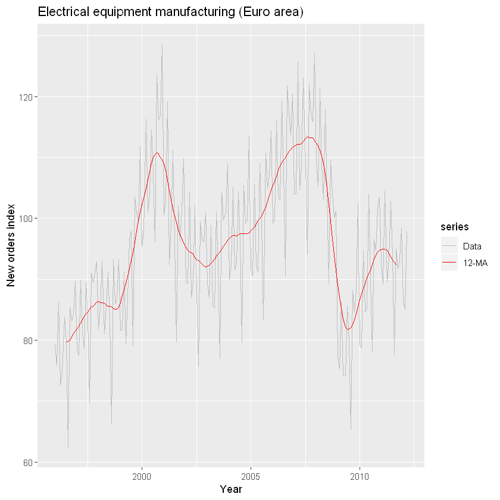

```r
#Figura 7:

autoplot(elecequip, series="Data") +
  autolayer(ma(elecequip, 12), series="12-MA") +
  xlab("Year") + ylab("New orders index") +
  ggtitle("Electrical equipment manufacturing (Euro area)") +
  scale_colour_manual(values=c("Data"="grey","12-MA"="red"),
                      breaks=c("Data","12-MA"))
```

La figura 7 muestra un 2×12-MA aplicado al índice de pedidos de equipos eléctricos. Observe que la línea suave no muestra estacionalidad; es casi lo mismo que el ciclo de tendencia que se muestra en la Figura 1, que se estimó utilizando un método mucho más sofisticado que un promedio móvil. Cualquier otra opción para el orden del promedio móvil (a excepción de 24, 36, etc.) habría dado como resultado una línea suave que mostró algunas fluctuaciones estacionales.

### Promedios móviles ponderados

Las combinaciones de promedios móviles dan como resultado promedios móviles ponderados. Por ejemplo, el 2×4-MA discutido anteriormente es equivalente a un 5-MA ponderado con pesos dados por: $$\left[\frac{1}{8},\frac{1}{4},\frac{1}{4},\frac{1}{4},\frac{1}{8}\right]$$

En general, una m-MA ponderada se puede escribir como:

$$\hat{T}_t = \sum_{j=-k}^k a_j y_{t+j}$$

donde k=(m-1)/2, y los pesos están dados por $\left[a_{-k},\dots,a_k\right]$

Es importante que todos los pesos sumen uno y que sean simétricos para que aj=a-j. El m-MA simple es un caso especial donde todos los pesos son iguales a 1/m.

Una ventaja importante de los promedios móviles ponderados es que producen una estimación más uniforme del ciclo de tendencia. En lugar de que las observaciones entren y salgan del cálculo con todo el peso, sus pesos aumentan lentamente y luego disminuyen lentamente, lo que resulta en una curva más suave.

## 3. Descomposición clásica

El método de descomposición clásico se originó en la década de 1920. Es un procedimiento relativamente simple y constituye el punto de partida para la mayoría de los otros métodos de descomposición de series temporales.

Hay dos formas de descomposición clásica: **descomposición aditiva** y **descomposición multiplicativa**. Estos se describen a continuación para una serie temporal con período estacional m (por ejemplo, m=4 para datos trimestrales, m=12 para datos mensuales, m=7 para datos diarios con un patrón semanal).

En la descomposición clásica, suponemos que el componente estacional es constante de año a año. Para la estacionalidad multiplicativa, la m los valores que forman el componente estacional a veces se denominan "**índices estacionales**".

### 3.1 Descomposición aditiva

### Paso 1

Si m es un número par, calcular el componente tendencia-ciclo $\hat{T}_t$ usando un 2×mMA. Si m es un número impar, calcular la tendencia - ciclo componente $\hat{T}_t$ usando un m-MA.

### Paso 2

Calcular las series sin tendencia: $y_t - \hat{T}_t$

### Paso 3

Para estimar el componente estacional de cada estacion, simplemente promedie los valores de tendencia de esa estacion. Por ejemplo, con los datos mensuales, el componente estacional de marzo es el promedio de todos los valores de marzo de tendencia en los datos. Estos valores de componentes estacionales se ajustan para garantizar que se sumen a cero. El componente estacional se obtiene al unir estos valores mensuales y luego replicar la secuencia para cada año de datos. Esto da: $\hat{S}_t$

### Paso 4

El componente de residuo se calcula restando las componentes estacionales y de tendencia-ciclo: $\hat{R}_t = y_t - \hat{T}_t - \hat{S}_t$

### 3.2 Descomposición multiplicativa

Una descomposición multiplicativa clásica es similar, excepto que las restas se reemplazan por divisiones.

### Paso 1

Si m es un número par, calcular el componente tendencia-ciclo $\hat{T}_t$ usando un 2×mMA. Si m es un número impar, calcular la tendencia - ciclo componente $\hat{T}_t$ usando un m-MA.

### Paso 2

Calcular las series sin tendencia: $y_t / \hat{T}_t$

### Paso 4

El componente de residuo se calcula dividiendo los componentes estacionales y de tendencia-ciclo $\hat{R}_{t} = y_t /( \hat{T}_t \hat{S}_t)$

La figura 8 muestra una descomposición clásica del índice del equipo eléctrico. Compare esta descomposición con la que se muestra en la Figura 1. La serie de valores residuo por debajo de 1 en 2009 sugiere que hay una cierta "fuga" del componente del ciclo de tendencia en el componente residuo. La estimación del ciclo de tendencia ha suavizado en exceso la caída de los datos, y los valores restantes correspondientes se han visto afectados por la estimación deficiente del ciclo de tendencia.

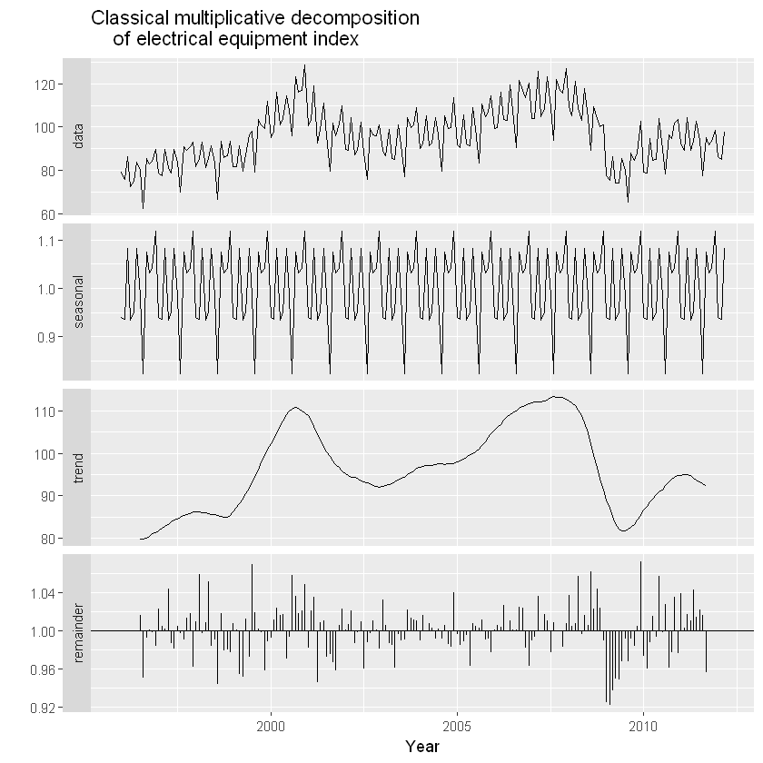

```r
## FIGURA 8

elecequip %>% decompose(type="multiplicative") %>%
  autoplot() + xlab("Year") +
  ggtitle("Classical multiplicative decomposition
    of electrical equipment index")
```

## Comentarios sobre la descomposición clásica

Si bien la descomposición clásica todavía se usa ampliamente, no se recomienda, ya que ahora hay varios métodos mucho mejores. Algunos de los problemas con la descomposición clásica se resumen a continuación.

1. La estimación del ciclo de tendencia no está disponible para las primeras y últimas pocas observaciones. Por ejemplo, si m=12, no hay una estimación del ciclo de tendencia para las primeras seis o las últimas seis observaciones. En consecuencia, tampoco existe una estimación del componente restante para los mismos períodos de tiempo.
2. La estimación del ciclo de tendencia tiende a suavizar los aumentos y caídas rápidos en los datos (como se ve en el ejemplo anterior).
3. Los métodos de descomposición clásicos suponen que el componente estacional se repite de año en año. Para muchas series, esta es una suposición razonable, pero para algunas series más largas no lo es. Por ejemplo, los patrones de demanda de electricidad han cambiado con el tiempo a medida que el aire acondicionado se ha generalizado. Específicamente, en muchos lugares, el patrón de uso estacional de hace varias décadas tuvo su demanda máxima en invierno (debido al calentamiento), mientras que el patrón estacional actual tiene su demanda máxima en verano (debido al aire acondicionado). Los métodos de descomposición clásicos no pueden capturar estos cambios estacionales a lo largo del tiempo.
4. Ocasionalmente, los valores de las series de tiempo en un pequeño número de períodos pueden ser particularmente inusuales. Por ejemplo, el tráfico mensual de pasajeros aéreos puede verse afectado por una disputa industrial, lo que hace que el tráfico durante la disputa sea diferente al habitual. El método clásico no es robusto para este tipo de valores inusuales.

## 4. Descomposición X11

Otro método popular para descomponer datos trimestrales y mensuales es el método X11 que se originó en la Oficina del Censo de los EE. UU. Y Statistics Canada.

Este método se basa en la descomposición clásica, pero incluye muchos pasos y características adicionales para superar los inconvenientes de la descomposición clásica que se discutieron en la sección anterior. En particular, las estimaciones del ciclo de tendencia están disponibles para todas las observaciones, incluidos los puntos finales, y el componente estacional puede variar lentamente con el tiempo. X11 también tiene algunos métodos sofisticados para manejar la variación del día de negociación, los efectos de vacaciones y los efectos de predictores conocidos. Maneja la descomposición aditiva y multiplicativa. El proceso es completamente automático y tiende a ser muy robusto para los valores atípicos y los cambios de nivel en las series de tiempo.

Los detalles del método X11 se describen en Dagum y Bianconcini (2016). Aquí solo demostraremos cómo usar el procedimiento automático en R.

El método X11 está disponible utilizando la función seas() del paquete seasonal en R.

```r
install.packages("seasonal")
```

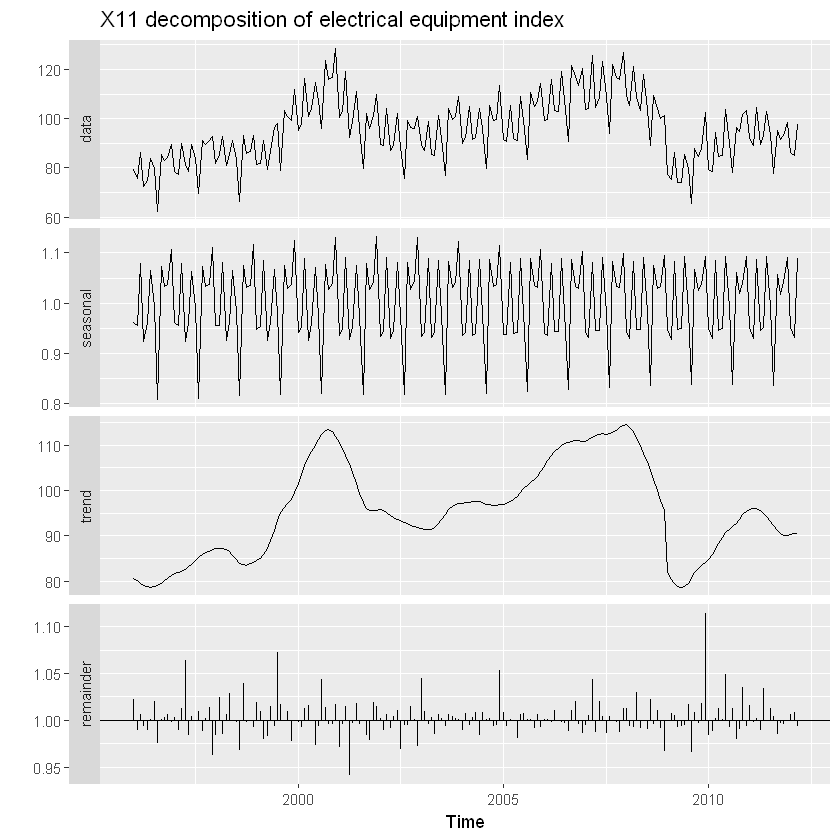

```r
#FIGURA 9

library(seasonal)
elecequip %>% seas(x11="") -> fit
autoplot(fit) +
  ggtitle("X11 decomposition of electrical equipment index")
```

Compare esta descomposición con la descomposición STL que se muestra en la Figura 1 y la descomposición clásica que se muestra en la Figura 8. El ciclo de tendencia X11 ha captado la caída repentina de los datos a principios de 2009 mejor que cualquiera de los otros dos métodos, y la observación inusual a finales de 2009 ahora se ve más claramente en el componente restante.

Dado el resultado de la función seas(), seasonal()extraerá el componente estacional, trendcycle() extraerá el componente del ciclo de tendencia, remainder() extraerá el componente residuo y seasadj() calculará la serie temporal ajustada estacionalmente.

Por ejemplo, la Figura 10 muestra el componente del ciclo de tendencia y los datos ajustados estacionalmente, junto con los datos originales.

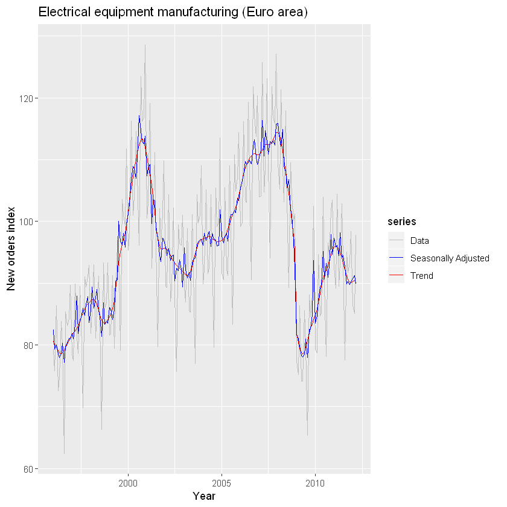

```r
#FIGURA 10

autoplot(elecequip, series="Data") +
  autolayer(trendcycle(fit), series="Trend") +
  autolayer(seasadj(fit), series="Seasonally Adjusted") +
  xlab("Year") + ylab("New orders index") +
  ggtitle("Electrical equipment manufacturing (Euro area)") +
  scale_colour_manual(values=c("gray","blue","red"),
             breaks=c("Data","Seasonally Adjusted","Trend"))
```

Puede ser útil utilizar gráficos estacionales y gráficos de sub-series estacionales del componente estacional. Estos nos ayudan a visualizar la variación en el componente estacional a lo largo del tiempo. La Figura 11 muestra una gráfica de sub-series estacionales del componente estacional de la Figura 9. En este caso, solo hay pequeños cambios a lo largo del tiempo.

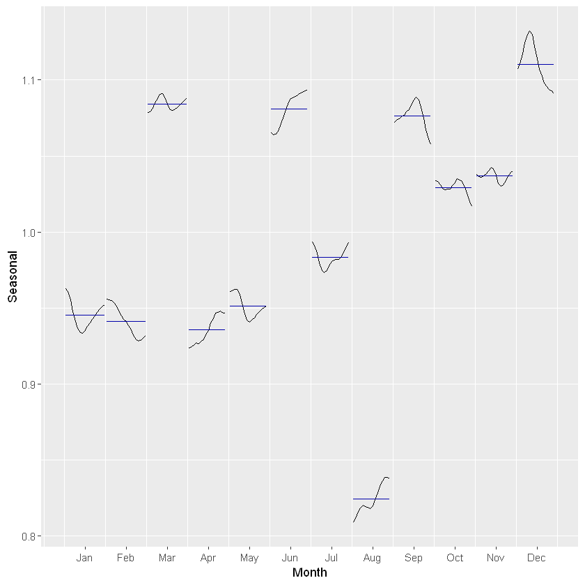

```r
#FIGURA 11

fit %>% seasonal() %>% ggsubseriesplot() + ylab("Seasonal")
```

## 5. Descomposición de SEATS

“SEATS” significa “Extracción estacional en la serie temporal de ARIMA”. Este procedimiento fue desarrollado en el Banco de España y ahora es ampliamente utilizado por agencias gubernamentales de todo el mundo. El procedimiento solo funciona con datos trimestrales y mensuales. Por lo tanto, la estacionalidad de otros tipos, como los datos diarios, los datos por hora o los datos semanales, requieren un enfoque alternativo.

Una discusión completa del método está disponible en Dagum y Bianconcini (2016). Aquí solo mostraremos cómo usarlo a través del paquete seasonal.

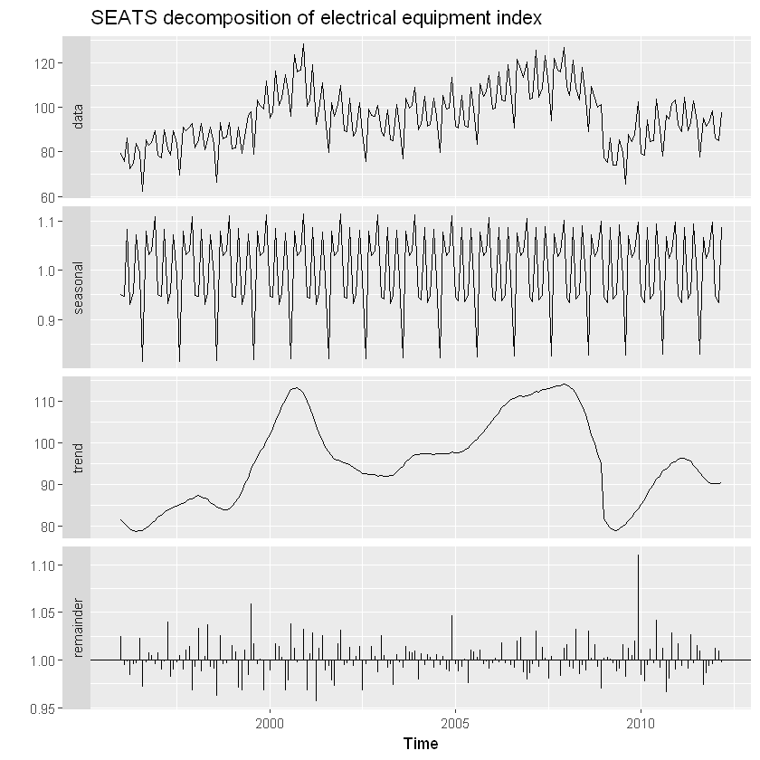

```r
# FIGURA 12

library(seasonal)
elecequip %>% seas() %>%
autoplot() +
  ggtitle("SEATS decomposition of electrical equipment index")
```

El resultado es bastante similar a la descomposición X11 que se muestra en la Figura 9.

Como con el método X11, podemos utilizar los seasonal(), trendcycle() y remainder() para extraer los componentes individuales, y seasadj() para calcular las series de tiempo ajustados estacionalmente.

El paquete seasonal tiene muchas opciones para manejar variaciones de X11 y SEATS.

Consulte el sitio web del paquete (http://www.seasonal.website/seasonal.html) para obtener una introducción detallada de las opciones y características disponibles.

## 6. Descomposición STL

STL es un método versátil y robusto para descomponer series temporales. STL es un acrónimo de "Descomposición estacional y de tendencia usando Loess", mientras que Loess es un método para estimar relaciones no lineales. El método STL fue desarrollado por Cleveland, Cleveland, McRae y Terpenning (1990).

STL tiene varias ventajas sobre los métodos de descomposición clásicos, SEATS y X11:

A diferencia de SEATS y X11, STL manejará cualquier tipo de estacionalidad, no solo datos mensuales y trimestrales.

El componente estacional puede cambiar con el tiempo, y el usuario puede controlar la tasa de cambio.

La suavidad del ciclo de tendencia también puede ser controlada por el usuario.

Puede ser robusto para los valores atípicos (es decir, el usuario puede especificar una descomposición robusta), de modo que las observaciones inusuales ocasionales no afectarán las estimaciones del ciclo de tendencia y los componentes estacionales. Sin embargo, afectarán el componente restante.

Por otro lado, STL tiene algunas desventajas. En particular, no maneja el día de negociación o la variación del calendario automáticamente, y solo proporciona facilidades para descomposiciones aditivas.

La mejor manera de comenzar a aprender a usar STL es ver algunos ejemplos y experimentar con la configuración. La Figura 2 muestra un ejemplo de STL aplicado a los datos de pedidos de equipos eléctricos. La Figura 13 muestra una descomposición alternativa de STL donde el ciclo de tendencia es más flexible, el componente estacional no cambia con el tiempo y se ha utilizado la opción robusta. Aquí, es más obvio que ha habido una bajada al final de la serie, y que los pedidos en 2009 fueron inusualmente bajos (correspondientes a algunos valores negativos grandes en el componente restante).

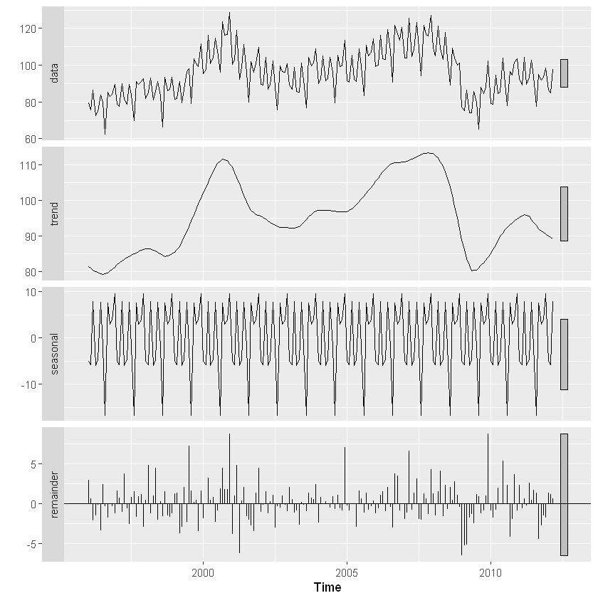

```r
#FIGURA 13

elecequip %>%
  stl(t.window=13, s.window="periodic", robust=TRUE) %>%
  autoplot()
```

Los dos parámetros principales que se elegirán al usar STL son la trend-cycle window (t.window) y la seasonal window ( s.window). Estos controlan qué tan rápido pueden cambiar el ciclo de tendencia y los componentes estacionales. Los valores más pequeños permiten cambios más rápidos. Los t.window y s.window deben ser números impares; t.windowes el número de observaciones consecutivas que se utilizarán al estimar el ciclo de tendencia; s.window es el número de años consecutivos que se utilizarán para estimar cada valor en el componente estacional. El usuario debe especificar s.window ya que no hay valor predeterminado. Establecerlo como infinito es equivalente a forzar que el componente estacional sea periódico (es decir, idéntico a través de los años). La especificación t.window es opcional y se usará un valor predeterminado si se omite.

La función mstl() proporciona una conveniente descomposición automática de STL usando s.window=13, y t.window también elegida automáticamente. Esto generalmente proporciona un buen equilibrio entre sobreajustar la estacionalidad y permitir que cambie lentamente con el tiempo. Pero, como con cualquier procedimiento automatizado, será necesario ajustar la configuración predeterminada para algunas series de tiempo.

## 7. Medición de la fuerza de tendencia y estacionalidad

Se puede utilizar una descomposición de series temporales para medir la fuerza de la tendencia y la estacionalidad en una serie temporal (Wang, Smith y Hyndman, 2006 ). Recuerde que la descomposición se escribe como: $$y_t = T_t + S_{t} + R_t$$

donde Tt es el componente de tendencia suavizado, St es el componente estacional y Rt es un componente residuo. Para datos con tendencia fuerte, los datos ajustados estacionalmente deberían tener mucha más variación que el componente restante. Por lo tanto, Var(Rt)/Var(Tt+Rt) debería ser relativamente pequeño. Pero para los datos con poca o ninguna tendencia, las dos variaciones deberían ser aproximadamente las mismas. Entonces definimos la fuerza de la tendencia como:

$$F_T = \max\left(0, 1 - \frac{\text{Var}(R_t)}{\text{Var}(T_t+R_t)}\right)$$

Esto dará una medida de la fuerza de la tendencia entre 0 y 1. Debido a que la varianza del resto ocasionalmente puede ser incluso mayor que la varianza de los datos ajustados estacionalmente, establecemos el valor mínimo posible de FT igual a cero

La fuerza de la estacionalidad se define de manera similar, pero con respecto a los datos de tendencia en lugar de los datos ajustados estacionalmente:

$$F_S = \max\left(0, 1 - \frac{\text{Var}(R_t)}{\text{Var}(S_{t}+R_t)}\right)$$

Una serie con fuerza estacional FS cerca de 0 exhibe casi ninguna estacionalidad, mientras que una serie con fuerte estacionalidad tendrá FS cerca de 1 porque Var(Rt)será mucho más pequeño que Var(St+Rt).

Estas medidas pueden ser útiles, por ejemplo, cuando tiene una gran colección de series de tiempo y necesita encontrar la serie con más tendencia o más estacionalidad.

## Forecasting con descomposicion

Si bien la descomposición es principalmente útil para estudiar datos de series de tiempo y explorar cambios históricos a lo largo del tiempo, también se puede usar en pronósticos.

Suponiendo una descomposición aditiva, la serie temporal descompuesta se puede escribir como: $$y_t = \hat{S}_t + \hat{A}_t$$

$$\hat{A}_t = \hat{T}_t+\hat{R}_{t}$$$$y_t = \hat{S}_t\hat{A}_t$$$$\hat{A}_t = \hat{T}_t\hat{R}_{t}$$

Para pronosticar una serie de tiempo descompuesto, pronosticamos el componente: $\hat{A}_t$

Para pronosticar el componente desestacionalizado, se puede utilizar cualquier método de pronóstico no estacional. Por ejemplo, **random walk with drift model**, o el método de **Holt**, o un modelo **ARIMA no estacional**.

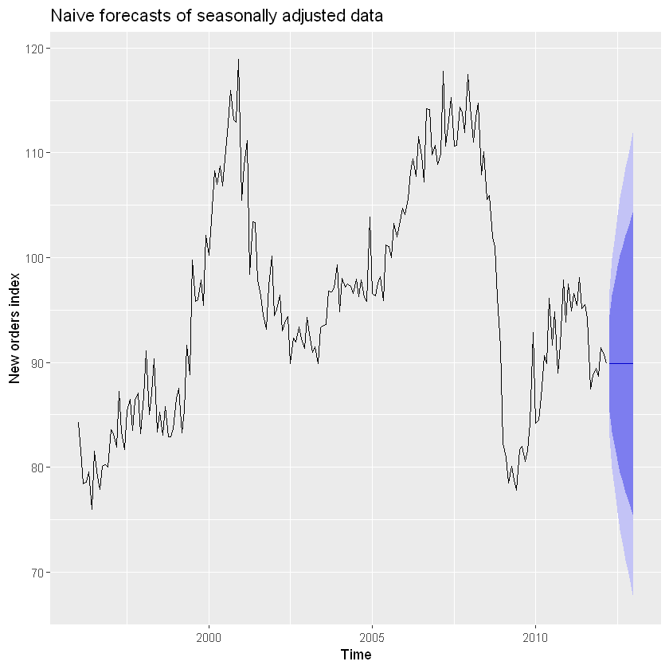

```r
#FIGURA 14
#Pronósticos Naives de los datos ajustados estacionalmente obtenidos de una descomposición STL.

fit <- stl(elecequip, t.window=13, s.window="periodic",
  robust=TRUE)
fit %>% seasadj() %>% naive() %>%
  autoplot() + ylab("New orders index") +
  ggtitle("Naive forecasts of seasonally adjusted data")
```

Estos se "reestacionalizan" al agregar los pronósticos naives estacionales del componente estacional.

Esto se hace fácil con la función forecast() aplicada al objeto stl. Debe especificar el método que se utiliza en los datos ajustados estacionalmente, y la función hará la reestacionalización por usted. Los pronósticos resultantes de los datos originales se muestran en la Figura 15 .

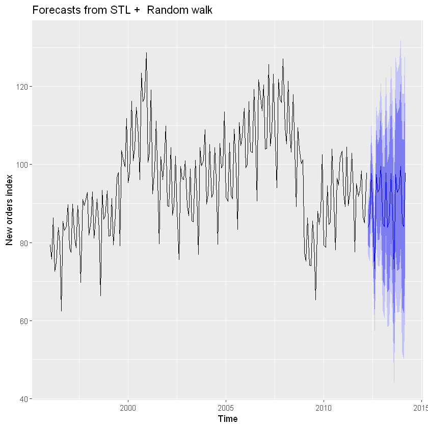

```r
fit %>% forecast(method="naive") %>%
  autoplot() + ylab("New orders index")
```

Los intervalos de predicción que se muestran en este gráfico se construyen de la misma manera que los pronósticos puntuales. Es decir, los límites superior e inferior de los intervalos de predicción en los datos ajustados estacionalmente se "reestacionalizan" al agregar los pronósticos del componente estacional. En este cálculo, se ha ignorado la incertidumbre en los pronósticos del componente estacional. La razón de esta elección es que la incertidumbre en el componente estacional es mucho menor que la de los datos ajustados estacionalmente, por lo que es una aproximación razonable ignorarlo.

Un enfoque abreviado es usar la función stlf(). El siguiente código descompondrá las series de tiempo usando STL, pronosticará las series ajustadas estacionalmente y devolverá los pronósticos reestacionalizados.

```r
fcast <- stlf(elecequip, method='naive')
```

La stlf() función utiliza mstl() para llevar a cabo la descomposición, por lo que hay valores predeterminados para s.window y t.window.

Si method no se especifica, utilizará el enfoque ETS (Exponential Smoothing) aplicado a la serie ajustada estacionalmente. Esto generalmente produce pronósticos bastante buenos para series temporales estacionales, y algunas compañías lo usan de manera rutinaria para todos sus pronósticos operativos.

## Anexo

### Algunos métodos de pronóstico simples

Algunos métodos de pronóstico son extremadamente simples y sorprendentemente efectivos.

### Método AVERAGE

Aquí, los pronósticos de todos los valores futuros son iguales al promedio (o "media") de los datos históricos. Si dejamos que los datos históricos se denoten por y1,...,yT, entonces podemos escribir los pronósticos como:

$$\hat{y}_{T+h|T} = \bar{y} = (y_{1}+\dots+y_{T})/T$$

La notación $\hat{y}_{T+h|T}$ es una abreviatura para la estimación de $\hat{y}_{T+h}$ basado en los datos y1,...,yT.

```r
meanf(y, h)
# y contains the time series
# h is the forecast horizon
```

### Método NAIVE

Para pronósticos ingenuos, simplemente establecemos que todos los pronósticos sean el valor de la última observación. Es decir, $$\hat{y}_{T+h|T} = y_{T}$$

Este método funciona notablemente bien para muchas series de tiempo económicas y financieras.

Debido a que un pronóstico naive es óptimo cuando los datos siguen una camino aleatorio, estos también se denominan **random walk forecasts**.

```r
naive(y, h)
rwf(y, h) # Equivalent alternative
```

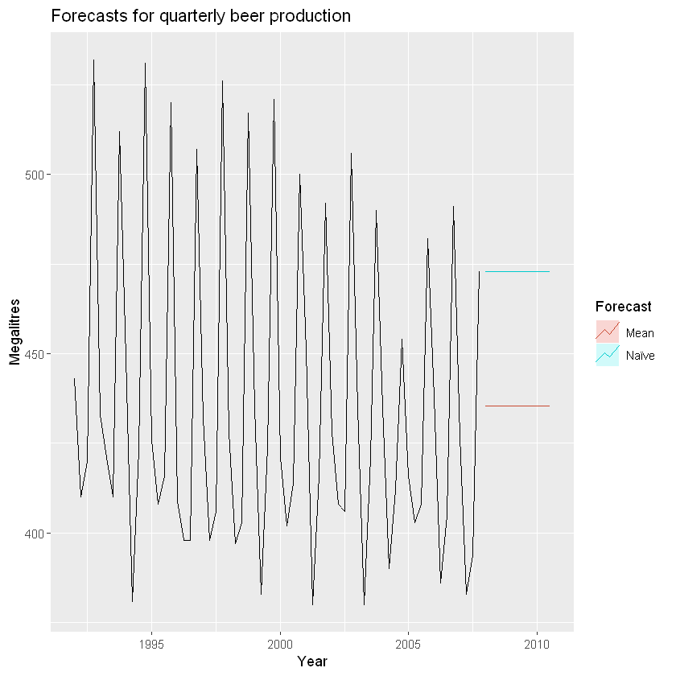

```r
# Set training data from 1992 to 2007
beer2 <- window(ausbeer,start=1992,end=c(2007,4))
# Plot some forecasts
autoplot(beer2) +
  autolayer(meanf(beer2, h=11),
    series="Mean", PI=FALSE) +
  autolayer(naive(beer2, h=11),
    series="Naïve", PI=FALSE) +
  ggtitle("Forecasts for quarterly beer production") +
  xlab("Year") + ylab("Megalitres") +
  guides(colour=guide_legend(title="Forecast"))
```

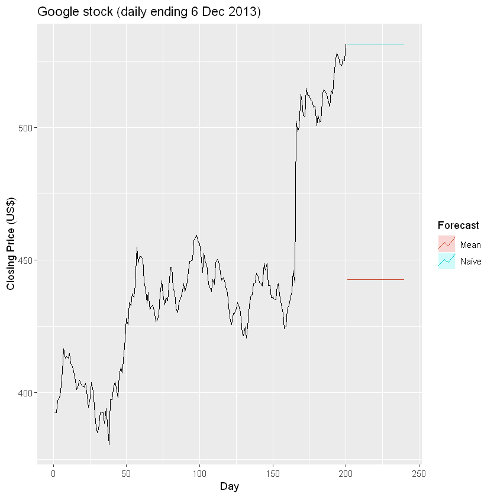

```r
autoplot(goog200) +
  autolayer(meanf(goog200, h=40),
    series="Mean", PI=FALSE) +
  autolayer(rwf(goog200, h=40),
    series="Naïve", PI=FALSE) +
  ggtitle("Google stock (daily ending 6 Dec 2013)") +
  xlab("Day") + ylab("Closing Price (US$)") +
  guides(colour=guide_legend(title="Forecast"))
```

## El paquete forecast en R

El paquete forecaste se carga cuando cargamos fpp2.

Muchas funciones, incluyendo meanf(), naive(), snaive()y rwf(), producen salidas en la forma de un objeto forecast (es decir, un objeto de clase forecast). Esto permite que otras funciones (como autoplot()) funcionen consistentemente en una variedad de modelos de pronóstico.

Los objetos de clase forecast contienen información sobre el método de pronóstico, los datos utilizados, los pronósticos puntuales obtenidos, los intervalos de predicción, los residuos y los valores ajustados. Hay varias funciones diseñadas para trabajar con estos objetos autoplot(), incluidos, summary() y print().

La siguiente lista muestra todas las funciones que producen objeto forecast.

- meanf()
- naive(), snaive()
- rwf()
- croston()
- stlf()
- ses()
- holt(), hw()
- splinef()
- thetaf()

### Function forecast ( )

Hasta ahora hemos usado funciones que producen un forecast objeto directamente. Pero un enfoque más común, es ajustar un modelo y luego usar la función forecast() para generar pronósticos a partir de ese modelo.

La función forecast() funciona con muchos tipos diferentes de entradas. Generalmente toma una serie de tiempo o un modelo de serie de tiempo como argumento principal, y produce pronósticos apropiadamente. Siempre devuelve objetos de clase forecast.

Si el primer argumento es de clase ts, devuelve pronósticos del algoritmo ETS.

Aquí hay un ejemplo simple, que se aplica forecast()a los datos ausbeer :

```r
forecast(ausbeer, h=4)
```

```
#>         Point Forecast Lo 80 Hi 80 Lo 95 Hi 95
#> 2010 Q3          404.6 385.9 423.3 376.0 433.3
#> 2010 Q4          480.4 457.5 503.3 445.4 515.4
#> 2011 Q1          417.0 396.5 437.6 385.6 448.4
#> 2011 Q2          383.1 363.5 402.7 353.1 413.1
```

Eso funciona bastante bien si no tienes idea de qué tipo de modelo usar. Caso contrario, deberá ajustar un modelo apropiado para los datos y luego lo usará forecast() para generar pronósticos a partir de ese modelo.

**Bibliografía**

- Forecasting: Principles and Practice Rob J Hyndman y George Athanasopoulos
- Machine Learning with R Cookbook - Second Edition 2017, by AshishSingh Bhatia, Chiu Yu-Wei, Packt Publishing.